# Visualizaciones — IBM HR Analytics Employee Attrition

Felipe Obregón Ochoa | Psicólogo

2026-06-01

```r
library(tidyverse)
library(patchwork)  # combinar múltiples gráficos
```

```r
df <- readr::read_csv("../data/WA_Fn-UseC_-HR-Employee-Attrition.csv")

# Eliminar columnas constantes (mismo criterio que notebook 01)
df <- df %>%
  select(-EmployeeCount, -Over18, -StandardHours, -EmployeeNumber)
```

# 1. Tasa de rotación por Departamento

**Nota metodológica:** Los gráficos a continuación muestran frecuencias y tasas de rotación por segmento organizacional. Las diferencias observadas entre grupos representan **asociaciones estadísticas**, no relaciones causales. Que un departamento o cargo presente una tasa de rotación más alta no implica que esa variable *cause* la salida — pueden existir factores confusores no medidos en este dataset. La confirmación de relaciones causales requiere diseños de investigación adicionales y se aborda parcialmente en el notebook 03 mediante modelado predictivo.

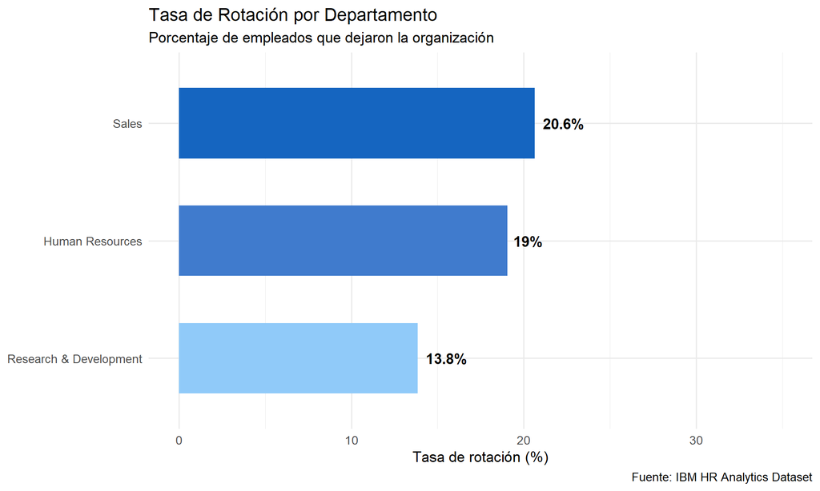

```r
plot_dept <- df %>%
  count(Department, Attrition) %>%
  group_by(Department) %>%
  mutate(tasa = n / sum(n) * 100) %>%
  filter(Attrition == "Yes") %>%
  ggplot(aes(x = reorder(Department, tasa), y = tasa, fill = tasa)) +
  geom_col(width = 0.6, show.legend = FALSE) +
  geom_text(aes(label = paste0(round(tasa, 1), "%")),
            hjust = -0.2, size = 4.5, fontface = "bold") +
  coord_flip() +
  scale_fill_gradient(low = "#90CAF9", high = "#1565C0") +
  scale_y_continuous(limits = c(0, 35)) +
  theme_minimal(base_size = 13) +
  labs(
    title    = "Tasa de Rotación por Departamento",
    subtitle = "Porcentaje de empleados que dejaron la organización",
    x        = NULL,
    y        = "Tasa de rotación (%)",
    caption  = "Fuente: IBM HR Analytics Dataset"
  )

plot_dept
```

```r
ggsave("../outputs/plots/01_rotacion_por_departamento.png",
       plot_dept, width = 10, height = 5, dpi = 150)
```

# 2. Tasa de rotación por JobRole (lollipop chart)

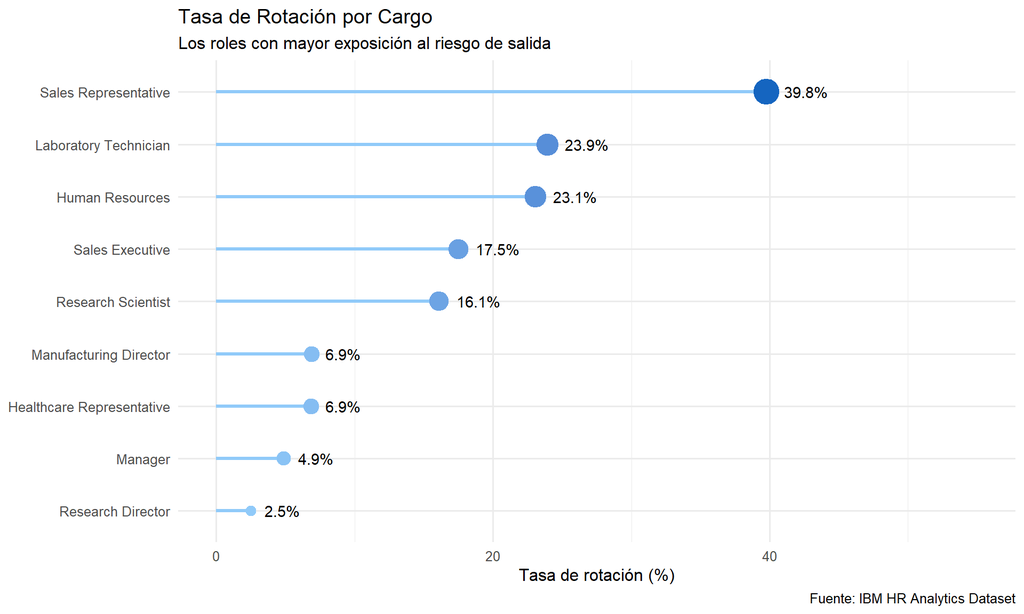

```r
plot_jobrole <- df %>%
  count(JobRole, Attrition) %>%
  group_by(JobRole) %>%
  mutate(tasa = n / sum(n) * 100) %>%
  filter(Attrition == "Yes") %>%
  ggplot(aes(x = reorder(JobRole, tasa), y = tasa)) +
  geom_segment(aes(xend = reorder(JobRole, tasa), y = 0, yend = tasa),
               color = "#90CAF9", linewidth = 1.2) +
  geom_point(aes(size = tasa, color = tasa), show.legend = FALSE) +
  geom_text(aes(label = paste0(round(tasa, 1), "%")),
            hjust = -0.4, size = 3.8) +
  coord_flip() +
  scale_color_gradient(low = "#90CAF9", high = "#1565C0") +
  scale_size_continuous(range = c(3, 8)) +
  scale_y_continuous(limits = c(0, 55)) +
  theme_minimal(base_size = 12) +
  labs(
    title    = "Tasa de Rotación por Cargo",
    subtitle = "Los roles con mayor exposición al riesgo de salida",
    x        = NULL,
    y        = "Tasa de rotación (%)",
    caption  = "Fuente: IBM HR Analytics Dataset"
  )

plot_jobrole
```

```r
ggsave("../outputs/plots/02_rotacion_por_cargo.png",
       plot_jobrole, width = 10, height = 6, dpi = 150)
```

# 3. Distribución de ingreso mensual por Attrition (violin + boxplot)

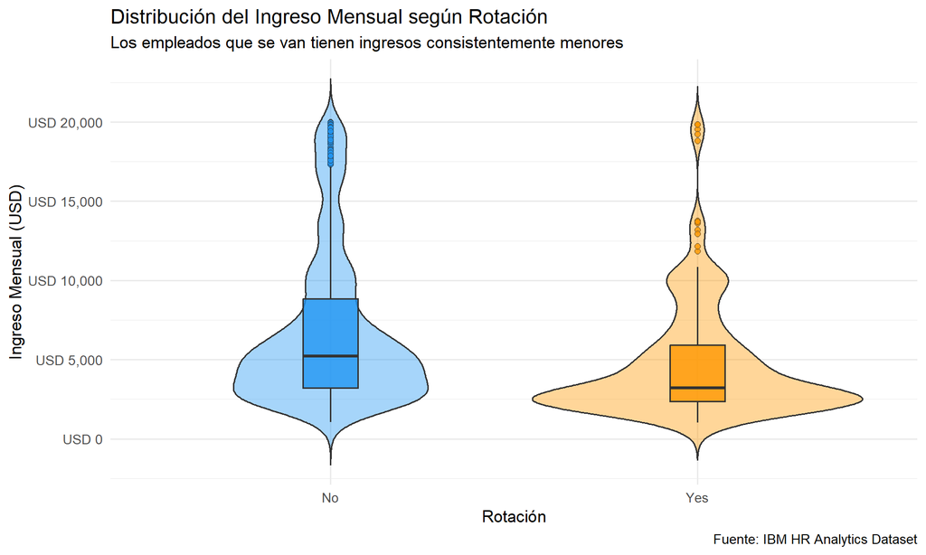

```r
plot_ingreso <- df %>%
  ggplot(aes(x = Attrition, y = MonthlyIncome, fill = Attrition)) +
  geom_violin(alpha = 0.4, trim = FALSE) +
  geom_boxplot(width = 0.15, alpha = 0.8, outlier.shape = 21,
               outlier.size = 2) +
  scale_fill_manual(values = c("No" = "#2196F3", "Yes" = "#FF9800")) +
  scale_y_continuous(labels = scales::dollar_format(prefix = "USD ")) +
  theme_minimal(base_size = 13) +
  theme(legend.position = "none") +
  labs(
    title    = "Distribución del Ingreso Mensual según Rotación",
    subtitle = "Los empleados que se van tienen ingresos consistentemente menores",
    x        = "Rotación",
    y        = "Ingreso Mensual (USD)",
    caption  = "Fuente: IBM HR Analytics Dataset"
  )

plot_ingreso
```

```r
ggsave("../outputs/plots/03_ingreso_por_attrition.png",
       plot_ingreso, width = 8, height = 6, dpi = 150)
```

## Nota interpretativa

La distribución del ingreso mensual según rotación no es homogénea dentro del grupo que se fue. Al observar la forma del violín en el grupo “Yes”, es posible identificar al menos dos concentraciones de densidad, lo que sugiere que no existe un único perfil salarial asociado a la salida voluntaria.

Esta heterogeneidad es consistente con lo que la literatura describe como dos momentos críticos en la trayectoria laboral. El primero ocurre en los años iniciales, cuando la satisfacción experimentada en el nuevo empleo comienza a declinar desde su punto más alto hacia un nivel de equilibrio inferior — fenómeno conocido como el efecto honeymoon-hangover (Boswell et al., 2005). Durante esta fase, la brecha entre las expectativas de ingreso y la compensación real puede actuar como detonante de la decisión de salida, especialmente cuando el empleado percibe que la organización no ha cumplido las promesas implícitas asociadas al proceso de incorporación (Rousseau, 1989).

El segundo momento aparece más avanzada la trayectoria, cuando empleados con mayor antigüedad y experiencia acumulada enfrentan barreras de desarrollo que limitan su progresión salarial y profesional. Este patrón es coherente con la noción de ruptura del contrato psicológico en su dimensión de desarrollo de carrera (Morrison y Robinson, 1997), donde la ausencia de oportunidades concretas de crecimiento erosiona el vínculo con la organización hasta que la salida se vuelve la respuesta más razonable.

Ambos momentos son prevenibles con intervenciones diferenciadas y oportunas, tal como se desarrolla en el notebook 03.

# 4. Heatmap de satisfacción laboral × rotación

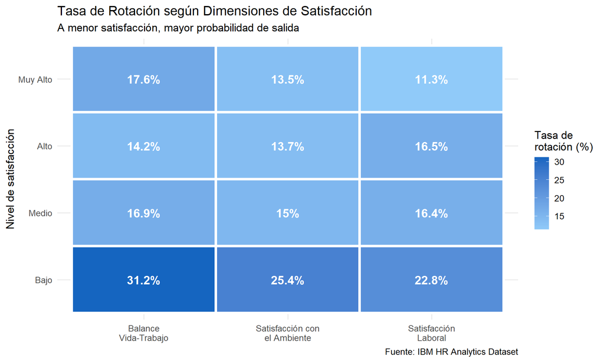

```r
# Calcular tasa de rotación promedio por nivel de satisfacción
heatmap_data <- df %>%
  select(Attrition, JobSatisfaction, EnvironmentSatisfaction, WorkLifeBalance) %>%
  mutate(Attrition_num = ifelse(Attrition == "Yes", 1, 0)) %>%
  pivot_longer(c(JobSatisfaction, EnvironmentSatisfaction, WorkLifeBalance),
               names_to = "dimension", values_to = "nivel") %>%
  group_by(dimension, nivel) %>%
  summarise(tasa_rotacion = mean(Attrition_num) * 100, .groups = "drop") %>%
  mutate(
    dimension = recode(dimension,
      "JobSatisfaction"         = "Satisfacción\nLaboral",
      "EnvironmentSatisfaction" = "Satisfacción con\nel Ambiente",
      "WorkLifeBalance"         = "Balance\nVida-Trabajo"
    ),
    nivel_label = recode(as.character(nivel),
      "1" = "Bajo", "2" = "Medio", "3" = "Alto", "4" = "Muy Alto"
    )
  )

plot_heatmap <- heatmap_data %>%
  ggplot(aes(x = dimension, y = factor(nivel_label, levels = c("Bajo","Medio","Alto","Muy Alto")),
             fill = tasa_rotacion)) +
  geom_tile(color = "white", linewidth = 1.5) +
  geom_text(aes(label = paste0(round(tasa_rotacion, 1), "%")),
            size = 5, fontface = "bold", color = "white") +
  scale_fill_gradient(low = "#90CAF9", high = "#1565C0",
                      name = "Tasa de\nrotación (%)") +
  theme_minimal(base_size = 13) +
  labs(
    title    = "Tasa de Rotación según Dimensiones de Satisfacción",
    subtitle = "A menor satisfacción, mayor probabilidad de salida",
    x        = NULL,
    y        = "Nivel de satisfacción",
    caption  = "Fuente: IBM HR Analytics Dataset"
  )

plot_heatmap
```

```r
ggsave("../outputs/plots/04_heatmap_satisfaccion.png",
       plot_heatmap, width = 10, height = 6, dpi = 150)
```

## Nota interpretativa

Desde la perspectiva del job embeddedness (Mitchell et al., 2001), estas tres dimensiones operan como indicadores de fit organizacional — la compatibilidad percibida entre el empleado y su entorno de trabajo. Estudios posteriores han confirmado que el fit es la dimensión del embeddedness más fuertemente asociada a la intención de salida, por sobre los vínculos relacionales y el sacrificio percibido (Jiang et al., 2012).

Lo que el heatmap muestra empíricamente es consistente con ese hallazgo: no es un único aspecto de la experiencia laboral el que predice la rotación, sino la convergencia de múltiples señales de desalineación. Un empleado con satisfacción laboral baja, ambiente deteriorado y balance vida-trabajo comprometido acumula evidencia suficiente para que la ruptura del contrato psicológico (Rousseau, 1989) se vuelva irreversible.

# 5. Impacto de horas extra (OverTime) en la rotación

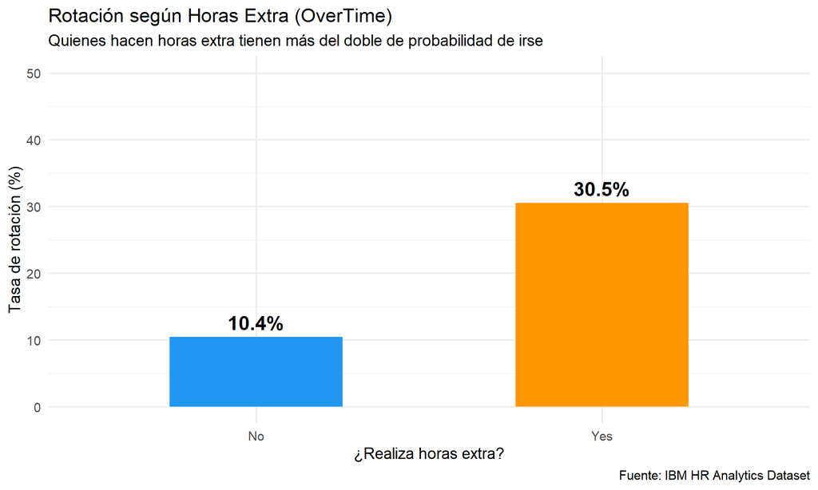

```r
plot_overtime <- df %>%
  count(OverTime, Attrition) %>%
  group_by(OverTime) %>%
  mutate(tasa = n / sum(n) * 100) %>%
  filter(Attrition == "Yes") %>%
  ggplot(aes(x = OverTime, y = tasa, fill = OverTime)) +
  geom_col(width = 0.5, show.legend = FALSE) +
  geom_text(aes(label = paste0(round(tasa, 1), "%")),
            vjust = -0.5, size = 6, fontface = "bold") +
  scale_fill_manual(values = c("No" = "#2196F3", "Yes" = "#FF9800")) +
  scale_y_continuous(limits = c(0, 50)) +
  theme_minimal(base_size = 14) +
  labs(
    title    = "Rotación según Horas Extra (OverTime)",
    subtitle = "Quienes hacen horas extra tienen más del doble de probabilidad de irse",
    x        = "¿Realiza horas extra?",
    y        = "Tasa de rotación (%)",
    caption  = "Fuente: IBM HR Analytics Dataset"
  )

plot_overtime
```

```r
ggsave("../outputs/plots/05_rotacion_overtime.png",
       plot_overtime, width = 7, height = 6, dpi = 150)
```

# 6. Años en la empresa y rotación

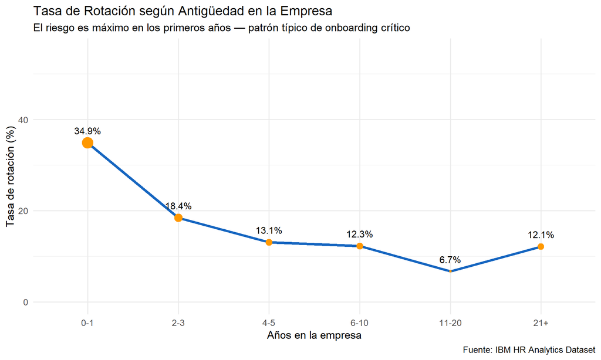

```r
plot_anios <- df %>%
  mutate(tramo_anios = cut(YearsAtCompany,
                           breaks = c(-1, 1, 3, 5, 10, 20, 40),
                           labels = c("0-1", "2-3", "4-5", "6-10", "11-20", "21+"))) %>%
  count(tramo_anios, Attrition) %>%
  group_by(tramo_anios) %>%
  mutate(tasa = n / sum(n) * 100) %>%
  filter(Attrition == "Yes") %>%
  ggplot(aes(x = tramo_anios, y = tasa, group = 1)) +
  geom_line(color = "#1565C0", linewidth = 1.5) +
  geom_point(aes(size = tasa), color = "#FF9800",
             show.legend = FALSE) +
  geom_text(aes(label = paste0(round(tasa, 1), "%")),
            vjust = -1.2, size = 4) +
  scale_y_continuous(limits = c(0, 55)) +
  theme_minimal(base_size = 13) +
  labs(
    title    = "Tasa de Rotación según Antigüedad en la Empresa",
    subtitle = "El riesgo es máximo en los primeros años — patrón típico de onboarding crítico",
    x        = "Años en la empresa",
    y        = "Tasa de rotación (%)",
    caption  = "Fuente: IBM HR Analytics Dataset"
  )

plot_anios
```

```r
ggsave("../outputs/plots/06_rotacion_por_antiguedad.png",
       plot_anios, width = 10, height = 6, dpi = 150)
```

## Nota interpretativa

Los dos gráficos anteriores concentran los hallazgos más relevantes del análisis exploratorio. El primero muestra que realizar horas extra casi triplica la probabilidad de salida voluntaria — 30.5% versus 10.4% en quienes no las realizan. El segundo confirma el patrón multimodal que se anticipó en el análisis de distribuciones: la rotación es máxima en los primeros años de antigüedad y desciende progresivamente, con un leve repunte pasados los 21 años.

Ambos patrones son coherentes con lo que la literatura describe. En el caso de las horas extra, la relación con la rotación ha sido documentada consistentemente como mediada por el agotamiento emocional — lo que Maslach y Leiter (1997) identificaron como el componente central del burnout organizacional. Cuando la demanda sostenida de tiempo supera los recursos disponibles del trabajador, la salida voluntaria emerge como la respuesta más accesible para recuperar el control sobre el propio tiempo y bienestar.

La curva de antigüedad, por su parte, es consistente con el efecto honeymoon-hangover descrito por Boswell et al. (2005): la caída brusca entre el primer y el tercer año refleja el período en que las expectativas iniciales colisionan con la experiencia organizacional real. El repunte observado después de los 21 años merece atención — podría indicar un segundo momento de vulnerabilidad asociado a cambios en las condiciones laborales o en las expectativas de retiro, aunque su interpretación requiere cautela dado el tamaño reducido de ese segmento en el dataset.

# 7. Edad vs ingreso mensual, coloreado por Attrition

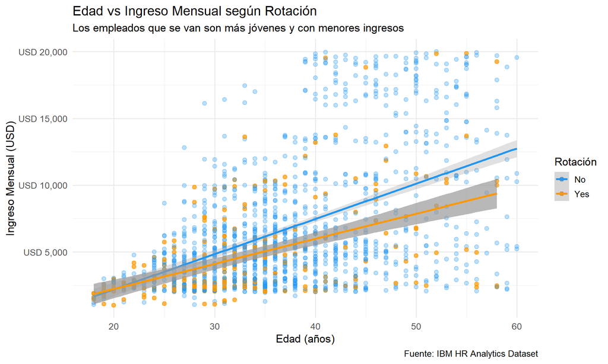

```r
plot_scatter <- df %>%
  ggplot(aes(x = Age, y = MonthlyIncome, color = Attrition, alpha = Attrition)) +
  geom_point(size = 2) +
  geom_smooth(method = "lm", se = TRUE, linewidth = 1.2) +
  scale_color_manual(values = c("No" = "#2196F3", "Yes" = "#FF9800"),
                     name = "Rotación") +
  scale_alpha_manual(values = c("No" = 0.3, "Yes" = 0.7), guide = "none") +
  scale_y_continuous(labels = scales::dollar_format(prefix = "USD ")) +
  theme_minimal(base_size = 13) +
  labs(
    title    = "Edad vs Ingreso Mensual según Rotación",
    subtitle = "Los empleados que se van son más jóvenes y con menores ingresos",
    x        = "Edad (años)",
    y        = "Ingreso Mensual (USD)",
    caption  = "Fuente: IBM HR Analytics Dataset"
  )

plot_scatter
```

```r
ggsave("../outputs/plots/07_edad_ingreso_attrition.png",
       plot_scatter, width = 10, height = 6, dpi = 150)
```

## Nota interpretativa

El gráfico de dispersión muestra la relación entre edad e ingreso mensual diferenciada por grupo de rotación. Ambos grupos presentan una asociación positiva entre ambas variables — a mayor edad, mayor ingreso — lo cual es esperable dado que la antigüedad y la experiencia acumulada tienden a traducirse en mayor compensación a lo largo de la trayectoria laboral.

Las líneas de tendencia incluyen intervalos de confianza al 95% representados por las bandas sombreadas. Su amplitud no es uniforme entre grupos: la banda del grupo que no rotó es notoriamente más angosta, lo que indica una estimación más precisa de la tendencia dado el mayor número de casos disponibles. La banda del grupo que sí rotó es más ancha — especialmente en los extremos de edad — reflejando mayor incertidumbre donde los datos son más escasos. Esta asimetría es en sí misma un hallazgo metodológico: las conclusiones sobre el perfil de rotación en empleados jóvenes o de mayor edad deben interpretarse con cautela adicional.

Lo relevante para el análisis de retención no es la pendiente sino el desplazamiento entre nubes: los empleados que se fueron se concentran sistemáticamente en la zona de menor ingreso relativo para su edad. Esto sugiere que la rotación no responde únicamente al nivel salarial absoluto, sino a una percepción de inequidad — la brecha entre lo que el empleado recibe y lo que considera proporcional a su experiencia y aporte (Adams, 1965). En términos de job embeddedness, esta percepción erosiona directamente la dimensión de sacrifice — el costo percibido de irse disminuye cuando el empleado siente que su compensación no refleja su contribución real (Mitchell et al., 2001).

# 8. Dashboard — 4 métricas clave

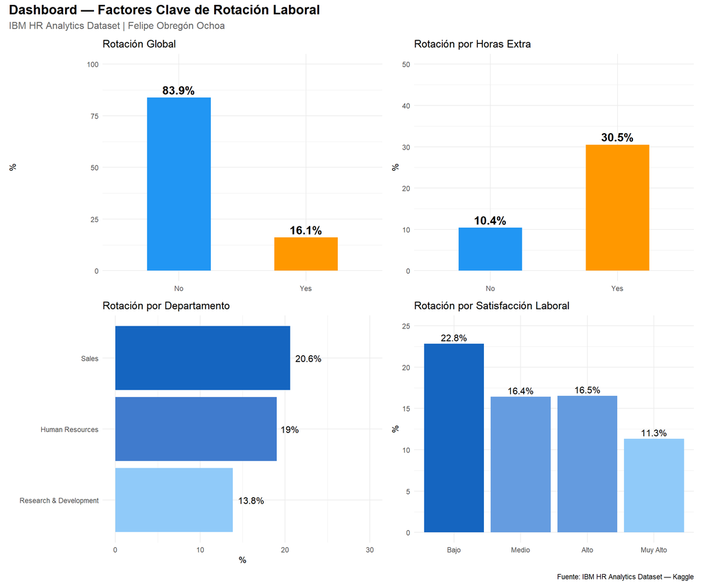

```r
# Métrica 1: Rotación global
p1 <- df %>%
  count(Attrition) %>%
  mutate(pct = n / sum(n) * 100) %>%
  ggplot(aes(x = Attrition, y = pct, fill = Attrition)) +
  geom_col(width = 0.5, show.legend = FALSE) +
  geom_text(aes(label = paste0(round(pct, 1), "%")),
            vjust = -0.4, fontface = "bold", size = 5) +
  scale_fill_manual(values = c("No" = "#2196F3", "Yes" = "#FF9800")) +
  scale_y_continuous(limits = c(0, 100)) +
  theme_minimal(base_size = 11) +
  labs(title = "Rotación Global", x = NULL, y = "%")

# Métrica 2: OverTime
p2 <- df %>%
  count(OverTime, Attrition) %>%
  group_by(OverTime) %>%
  mutate(pct = n / sum(n) * 100) %>%
  filter(Attrition == "Yes") %>%
  ggplot(aes(x = OverTime, y = pct, fill = OverTime)) +
  geom_col(width = 0.5, show.legend = FALSE) +
  geom_text(aes(label = paste0(round(pct, 1), "%")),
            vjust = -0.4, fontface = "bold", size = 5) +
  scale_fill_manual(values = c("No" = "#2196F3", "Yes" = "#FF9800")) +
  scale_y_continuous(limits = c(0, 50)) +
  theme_minimal(base_size = 11) +
  labs(title = "Rotación por Horas Extra", x = NULL, y = "%")

# Métrica 3: Departamento
p3 <- df %>%
  count(Department, Attrition) %>%
  group_by(Department) %>%
  mutate(pct = n / sum(n) * 100) %>%
  filter(Attrition == "Yes") %>%
  ggplot(aes(x = reorder(Department, pct), y = pct, fill = pct)) +
  geom_col(show.legend = FALSE) +
  geom_text(aes(label = paste0(round(pct, 1), "%")),
            hjust = -0.2, size = 4) +
  coord_flip() +
  scale_fill_gradient(low = "#90CAF9", high = "#1565C0") +
  scale_y_continuous(limits = c(0, 30)) +
  theme_minimal(base_size = 11) +
  labs(title = "Rotación por Departamento", x = NULL, y = "%")

# Métrica 4: Satisfacción laboral
p4 <- df %>%
  mutate(Attrition_num = ifelse(Attrition == "Yes", 1, 0)) %>%
  group_by(JobSatisfaction) %>%
  summarise(tasa = mean(Attrition_num) * 100) %>%
  ggplot(aes(x = factor(JobSatisfaction), y = tasa, fill = tasa)) +
  geom_col(show.legend = FALSE) +
  geom_text(aes(label = paste0(round(tasa, 1), "%")),
            vjust = -0.4, size = 4) +
  scale_fill_gradient(low = "#90CAF9", high = "#1565C0") +
  scale_y_continuous(limits = c(0, 25)) +
  scale_x_discrete(labels = c("1" = "Bajo", "2" = "Medio",
                               "3" = "Alto", "4" = "Muy Alto")) +
  theme_minimal(base_size = 11) +
  labs(title = "Rotación por Satisfacción Laboral", x = NULL, y = "%")

# Combinar con patchwork
dashboard <- (p1 + p2) / (p3 + p4) +
  plot_annotation(
    title    = "Dashboard — Factores Clave de Rotación Laboral",
    subtitle = "IBM HR Analytics Dataset | Felipe Obregón Ochoa",
    caption  = "Fuente: IBM HR Analytics Dataset — Kaggle",
    theme    = theme(
      plot.title    = element_text(size = 16, face = "bold"),
      plot.subtitle = element_text(size = 12, color = "gray40")
    )
  )

dashboard
```

```r
ggsave("../outputs/plots/08_dashboard_metricas.png",
       dashboard, width = 12, height = 10, dpi = 150)
```

## Síntesis visual — Dashboard de factores clave

El dashboard integra los cuatro hallazgos con mayor relevancia para la intervención organizacional. La tasa global de rotación del 16.1% establece la magnitud del problema. Las horas extra emergen como el factor de riesgo más potente — triplicando la probabilidad de salida — lo que es consistente con la literatura sobre agotamiento emocional como antecedente de la rotación voluntaria (Maslach y Leiter, 1997). La distribución por departamento señala focos de intervención prioritaria, mientras que la satisfacción laboral opera como indicador temprano de deterioro del fit organizacional (Mitchell et al., 2001).

La lectura conjunta de estos cuatro indicadores permite pasar de un diagnóstico descriptivo a una agenda de intervención concreta — que se desarrolla en el notebook 03 mediante modelado predictivo.

**Nota metodológica:** Variables como `JobSatisfaction`, `EnvironmentSatisfaction` y `WorkLifeBalance` son escalas ordinales (Likert de 4 puntos). Para efectos del modelado predictivo se tratan como numéricas asumiendo escala intervalar — decisión documentada como limitación psicométrica en el notebook 03.

## Referencias

Adams, J. S. (1965). Inequity in social exchange. En L. Berkowitz (Ed.), Advances in experimental social psychology (Vol. 2, pp. 267–299). Academic Press.

Boswell, W. R., Boudreau, J. W., y Tichy, J. (2005). The relationship between employee job change and job satisfaction: The honeymoon-hangover effect. Journal of Applied Psychology, 90(5), 882–892.

Jiang, K., Liu, D., McKay, P. F., Lee, T. W., y Mitchell, T. R. (2012). When and how is job embeddedness predictive of turnover? A meta-analytic investigation. Journal of Applied Psychology, 97(5), 1077–1096.

Maslach, C., y Leiter, M. P. (1997). The truth about burnout: How organizations cause personal stress and what to do about it. Jossey-Bass.

Mitchell, T. R., Holtom, B. C., Lee, T. W., Sablynski, C. J., y Erez, M. (2001). Why people stay: Using job embeddedness to predict voluntary turnover. Academy of Management Journal, 44(6), 1102–1121.

Morrison, E. W., y Robinson, S. L. (1997). When employees feel betrayed: A model of how psychological contract violation develops. Academy of Management Review, 22(1), 226–256.

Rousseau, D. M. (1989). Psychological and implied contracts in organizations. Employee Responsibilities and Rights Journal, 2(2), 121–139.